# COVID19 analysis

# Данные

Data table. New column names

age

sex

COVID

test.type

transmission.type

bad.contacts

risk.factors

hyposmia.before

when.noticed

olfactory.loss

other.symptoms

column.1

stat.amb

progress

current.state

anosmia.regress

n.days.regress

58

м

Положит.

3

нет

1

13

да

до диагн.

1

нет

9

амбулаторн

без изм.

здоров

да

до 14 дней

50

ж

Положит.

1

Да

мед.работник

2,9,13,14

нет

до диагност.

1.5

да

2,3,4,5,6,7,9

стац.госпит.

ухудш.

здоров

да

через 14д., до 30

58

м

Положит.

1

нет

тесн.контакт

2,9,14

нет

до диагн.

2.5

да

NA

стац.госпит.

без изм.

здоров

да

до 14 дней

56

м

Положит.

1

нет

нет

1

нет

нет аносм

нет симптомов

нет

NA

амб.

улучш.

здоров

не было

не было

45

м

Отриц.

1

нет

нет

1

нет

нет

нет

нет

NA

амб.

не было аносмии

течение

не было

нет аносм

25

ж

Отриц.

1

нет

мед.работник

1

нет

до диагн

2.5

да

NA

амб.

улучш.

выздоровл

да

до 14 дней

61

ж

Отриц.

3

нет

1

2

нет

нет аносм

NA

нет

NA

стац.госпит.

не было аносмии

здоров

не было

не было

40

м

Отриц.

1

нет

NA

NA

нет

до диагн

5

нет

NA

стац.госпит.

улучш.

здоров

регресс

66

ж

Отриц.

1

нет

1

2

нет

нет симптомов

NA

нет

NA

стац.госпит.

не было аносмии

течение

не было

не было

52

ж

Отриц.

1

нет

1

1

нет

нет таких симптомов

нет симптомов

NA

NA

NA

NA

NA

не было

не было

76

м

Положит.

4

да

1

2

нет

до диагн

1

NA

NA

NA

NA

здоров

NA

NA

74

м

Отриц.

3

нет

2

8.9

нет

нет симптомов

NA

NA

NA

NA

NA

NA

не было

не было

35

м

Положит.

1

нет

1

1

нет

нет симптомов

NA

NA

NA

NA

NA

здоров

не было

не было

56

м

Положит.

1

нет

NA

12.14

нет

до диагн.

1,2,3

да

NA

амб.

ухудш: t +

течение

нет

пока не регресс

59

ж

Отриц.

1

нет

NA

NA

нет

нет симптомов

NA

NA

NA

NA

NA

NA

не было

не было

55

ж

Положит.

1

да

7

8.15

нет

после диагн

7.8

нет

NA

NA

NA

NA

NA

NA

72

ж

Положит.

1

нет

1

2.13

нет

нет симптомов

NA

NA

NA

стац.госпит.

NA

течение

да

через 14, до 30

66

ж

Положит.

3

нет

NA

7,8,13,14

нет

до диагн

2.2999999999999998

да

NA

амб.

NA

NA

NA

NA

61

ж

Положит.

1

нет

5

2.13

нет

нет симптомов

NA

NA

NA

амб

NA

здоров

не было

не было

64

м

в работе

3

нет

7

8

нет

до диагн, 3й день

5

нет

NA

стац.госпит.

NA

здоров

регресс

до 14 дней

46

м

Положит.

1

нет

1

15

нет

нет симптомов

NA

NA

NA

NA

NA

NA

не было

не

68

м

предПоложит пол.

3

да

3

1

нет

нет симптомов

NA

NA

NA

стац.госпит.

NA

NA

не было

не было

71

м

Отриц.

1

нет

1

2

да

5й день до диагн

3.5

нет

NA

амб

NA

здоров

NA

NA

36

м

Положит.

1

нет

3

1

нет

до диагн,8й день

1.5

да

NA

амб

улуЧШ, t -

здоров

регресс

до 14 дней

48

м

в работе

1

нет

NA

1

нет

после диагн

1

да

NA

амб

без изм.

здоров

регресс

до 14 дней

53

ж

Отриц.

3

нет

1

1

нет

нет симптомов

NA

NA

NA

стац.госпит.

NA

здоров

не было

не было

36

м

Отриц.

1

Да

1

1

нет

нет симптомов

NA

NA

NA

стац.госпит.

NA

NA

не было

не было

74

м

Отриц.

1

Да

5

2

нет

нет симптомов

NA

NA

NA

стац.госпит.

NA

здоров

не было

не было

73

ж

Положит.

1

нет

NA

NA

нет

3-4й день до диагн

2,3,4

NA

NA

амб.

NA

NA

регресс

до 14 дней

33

м

Отриц.

1

нет

7

7

да

после диагн.

2

да

NA

стац.госпит.

ухудщ.одышк

здоров

регресс

до 14 дней

45

м

в работе

3

нет

7

1

нет

до диагн.

1.5

нет

NA

амб.

ухудш. Диспепсия

здоров

регресс

до 14 дней

72

ж

Положит.

1

нет

3

2,9,10,13,14

нет

до диагн.

1.7

да

NA

стац.госпит.

ухудш.

здоров

регресс

до 14 дней

56

м

Положит.

1

нет

1

5,9,14

нет

до диагн.

2.3,5

да

NA

стац.госпит.

ухудш.

здоров

регресс

до 14 дней

60

м

Отриц.

1

нет

1

2.9

нет

до диагн

1.5

да

NA

стац.госпит.

ухуддш.

здоров

регресс

до 14 дней

55

м

Положит.

1

Да

3

2,8,9,14

нет

до диагн.

2.5

да

NA

стац.госпит.

ухудш.

здоров

регресс

до 14 дней

74

м

Положит.

1

нет

1

2.9

нет

до диагн.

1

нет

NA

стац.госпит.

ухудш

здоров

регресс

через 14, до 30

25

ж

Отриц.

1

Да

2

4

нет

до диагн.

2.6

нет

NA

амб.

без изм.

здоров

регресс

до 14 дней

71

м

Положит.

1

нет

7

2

нет

10й день, до диагн.

1.5

нет

NA

амб.

NA

здоров

регресс

до 14 дней

60

ж

Отриц.

1

нет

NA

NA

нет

нет данных

NA

NA

NA

NA

NA

NA

NA

NA

84

ж

Отриц.

1

нет

NA

8.1300000000000008

нет

нет данных

NA

NA

NA

NA

NA

течение

не было

не было

59

ж

Положит.

1

нет

1

8,9,13

нет

до диагн

2

да

NA

стац.госпит.

ухудш.

здоров

регресс

не было

72

м

в работе

3

нет

3

2

нет

до диагн.

1.5

да

NA

стац.госпит.

ухудш, t+

здоров

регресс

до 14 дней

67

м

Отриц.

1

нет

1

NA

нет

нет симптомов

8

нет

NA

стац.госпит.

х

здоров

не было

не было

54

м

Положит.

1

нет

7

1

нет

нет симптомов

NA

NA

NA

NA

не было аносмии

течение

не было

не было

68

ж

Положит.

1

нет

2

13

нет

после диагн.

1

нет

NA

стац.госпит.

ухудш.

здоров

регресс

до 14 дней

22

ж

Положит.

1

Да

2.2999999999999998

1

нет

до диагн.

2.5

да

NA

амб

ухудш.

здоров

регресс

до 14 дней

33

м

Отриц.

1

нет

1

1

нет

нет симптомов

8

NA

NA

стац.госпит.

улучш,, пропали боли в груди

здоров

нет

пока не регресс

47

м

Отриц.

1

нет

1

1

да

до диагн

3.5

нет

NA

стац.госпит.

улучш.

здоров

регресс

через 14,до 30

NA

м

Положит.

1

нет

1

NA

нет

нет симптомов

NA

NA

NA

стац.госпит.

улучш.

течение

не было

не было

46

ж

Положит.

1

нет

7

2,9,14

да

до диагн, 4-5й день

2

NA

NA

стац.госпит.

ухудш., слабость

течение

регресс

до 14 дней

50

ж

Отриц.

1

нет

7

1

нет

нет таких симптомов

8

нет

NA

стац.госпит.

не было аносмии

течение

не было

не было

52

ж

Отриц.

1

нет

3

1

нет

нет таких симптомов

NA

NA

NA

стац.госпит.

не было аносмии

течение

не было

не было

59

м

Отриц.

1

нет

1

7,8,13

да

обоняние отсутствовало до болезни

2

да

NA

стац.госпит.

не было аносмии

здоров

нет

пока не регресс

77

ж

предПоложит пол

4

да

NA

2,9,12,13,14

нет

нет таких симптомов

NA

NA

NA

стац.госпит.

не было аносмии

течение

нет

нет аносм

58

м

Положит.

1

да

3

7

да

до диагн

2

нет

NA

амб.

не изменилось

здоров

регресс

до 14 дней

40

ж

Отриц.

1

нет

1

3

нет

нет таких симптомов

NA

да

NA

амб.

не было аносмии

здоров

не было

не было

72

ж

в работе

1

нет

NA

2.13

нет

нет данных

NA

NA

NA

стац.госпит.

не было аносмии

течение

не было

не было

74

м

Отриц.

1

нет

2

2

нет

нет таких симптомов

NA

NA

NA

cтац

не было аносмии

течение

не было

не было

61

м

Отриц.

3

нет

1

8

да

до диагн

2

да

NA

амб.

ухухдш: боли в мышцах, слабость, затруднение дыхания

здоров

да

через 14,до 30

59

ж

Отриц.

1

нет

не данных

1

нет

нет таких симптомов

NA

NA

NA

стац.госпит.

не было аносмии

здоров

не было

не было

42

ж

Положит.

1

да

1

1

нет

5-й день, до диагн.

1

да

NA

амб.

ухудш.

здоров

регресс

до 14 дней

42

м

Положит.

1

нет

1

8

нет

нет таких симптомов

NA

нет

NA

стац.госпит.

не было аносмии

течение

не было

нет

50

м

Положит.

1

нет

7

2

нет

нет таких симптомов

отсутствуют

х

NA

амб.

не было аносмии

здоров

не было

не было

50

м

Отриц.

1

нет

1

13

да

до диагност.

1.2

нет

NA

амб.

улучш.

здоров

да

до 14 дней

49

ж

Положит.

1

да

3

1

нет

нет таких симптомов

х

нет

NA

амб

не было аносмии

течение

не было

не было

56

ж

Отриц.

1

нет

1

1

нет

на 4й день

2

нет

NA

амб

не изменилось

течение

пока не регресс

пока не регресс

26

ж

Положит.

2

нет

2

1

нет

до диагн., 3й день

2.5

да

NA

амб

улулчш., норм. T

здоров

регресс

до 14 дней

55

м

Положит.

1

нет

1

1

да

до диагн.,5й день

2.5

нет

NA

амб

ухудш,t+

здоров

регресс

через 14, до 30

38

ж

Положит.

1

нет

1

1

нет

до диагн., 3й день

2.5

нет

NA

стац.госпит.

без изм.

здоров

регресс

через 14, до 30

63

м

Положит.

1

нет

1

1

нет

нет таких симптомов

нет

да

NA

стац.госпит.

нет аносм

здоров

нет данных

нет данных

40

ж

преПоложит пол

3

да

1

7

да

до диагн.

2.5

нет

NA

амб.

ухудш.

здоров

регресс

до14 дней

54

ж

Положит.

3

нет

7

9.15

нет

после диагн. 2-3й

2,3,5

нет

NA

стац.госпит.

ухудш.

течение

регресс

через 14, до 30

24

ж

предПоложит пол

2

нет

2

1

да

4й день

2,6,7

да

NA

амб.

улучш. Норм t

здоров

регресс

через 14 до 30

34

м

Отриц.

1

Да

5

1

нет

нет таких симптомов

ххх

да

NA

стац.госпит.

ххх

течение

не было

не было

57

м

Положит.

1

Да

1

9

нет

3й день до диагн.

1

нет

NA

амб.

ухудш.,t+

здоров

регресс

до 14 дней

28

ж

Положит.

3

Да

1

1

нет

нет таких симптомов

нет симптомов

да

NA

стац.госпит.

нет аносм

течение

не было

нет аносм

48

ж

в работе

1

да

2

1

нет

3й день до диагн.

2

нет

NA

амб.

ухудш.

здоров

регресс

до 14 дней

61

м

Положит.

3

нет

1

9

нет

нет таких симптомов

нет симптомов

да

NA

стац.госпит.

ххх

здоров

нет данных

нет данных

36

м

Отриц.

3

нет

1

1

нет

нет таких симптомов

нет симптомов

нет

NA

стац.госпит.

ххх

здоров

нет данных

нет данных

72

ж

Отриц.

3

нет

1

9

нет

нет таких симптомов

NA

нет

NA

амб

ххх

здоров

нет данных

нет данных

44

ж

Положит.

1

нет

1

7

нет

4й день

1

нет

NA

стац.госпит.

без изм.

здоров

регресс

до 14 дней

41

ж

Положит.

3

Да

2

1

нет

4й день

2.5

да

NA

амб.

улучш., t норм, кашель уменьш.

здоров

регресс

через 14, до 30

44

м

Отриц.

1

нет

1

14

нет

нет симптомов

нет симптомов

нет

NA

стац.госпит.

нет аносм

здоров

нет данных

нет данных

59

м

Положит.

3

нет

1

1

нет

4й день

1.7

нет

NA

амб

без изм.

здоров

нет

пока не регресс

34

ж

Положит.

2

нет

2

1

нет

3й день до диагн.

2

нет

NA

амб.

без изм.

здоров

регресс

до 14 дней

46

м

в работе

3

нет

1

1

нет

нет симптомов

нет

да

NA

амб.

нет аносм

здоров

нет данных

нет данных

46

м

Положит.

1

нет

1

1

нет

нет симптомов

нет

нет

NA

амб.

нет аносм

здоров

нет аносм

нет аносм

42

м

Положит.

1

Да

3

9.14

нет

нет симптомов

нет

нет

NA

амб.

нет аносм

течение

нет аносм

нет аносм

50

ж

Положит.

1

нет

1

7.14

да

3й день до диагн.

3.5

нет

NA

амб.

улулчш. T N

здоров

регресс

до 14 дней

38

ж

Положит.

3

нет

2

5

нет

2й день

1

нет

NA

амб.

без изм.

здоров

регресс

до 14 дней

71

м

Положит.

1

нет

1

2, 8,9

нет

после диагн.

5

нет

NA

стац.госпит.

ухудш.

течение

пока не регресс

пока не регресс

62

м

в работе

1

нет

1

5,7,8,9,11,15

нет

нет аносм

нет

нет

NA

стац.госпит.

нет аносм

течение

нет аносм

нет аносм

79

ж

Отриц.

1

нет

1

2,7,8,9,13,14

да

до диагн.

8

да

NA

амб.

ухухдш. Одышка

течение

регресс

через 14, до 30

70

м

Положит.

1

нет

1

2

нет

нет симптомов

нет

нет

NA

амб.

нет аносм

течение

нет аносм

нет аносм

48

ж

Положит.

1

Да

3

14

да

нет симптомов

нет

да

NA

стац.госпит.

нет аносм

здоров

нет аносм

нет аносм

73

ж

Положит.

1

нет

1

2

нет

нет симптомов

нет

нет

NA

стац.госпит.

нет аносм

здоров

нет аносм

нет аносм

39

м

Положит.

1

нет

1

6

нет

до диагн.

2,3,6,7

нет

NA

амб.

ухудш.

здоров

нет

пока не регресс

39

м

Отриц.

4

нет

7

1

нет

нет симптомов

нет

нет

NA

амб.

нет аносм

здоров

нет аносм

нет аносм

40

ж

в работе

3

нет

1

1

нет

4й день

2.5

нет

NA

стац.госпит.

ухудш. Тошнота усталость

здоров

пока не регресс

пока не регресс

38

м

Положит.

1

нет

1

15

нет

нет аносм

нет симптомов

нет

NA

стац.госпит.

нет аносм

здоров

нет аносм

нет аносм

49

м

предПоложит пол

2

да

1

4,5,6,7,8,10,12

нет

3й день до диагн.

5,7,8

да

NA

амб.

без изм.

здоров

регресс

до 14 дней

49

м

Положит.

3

нет

1

9

нет

4й день после диагн

1

нет

NA

амб.

без изм.

здоров

регресс

до 14 дней

63

м

Отриц.

3

нет

1

13

нет

нет аносм

нет

нет

NA

амб.

нет аносм

здоров

нет аносм

нет аносм

49

м

Положит.

1

нет

1

1

нет

3й день после

1

нет

NA

амб.

без изм.

течение

пока не регресс

пока не регресс

71

м

Положит.

1

нет

1

2.9

нет

нет таких симптомов

нет

нет

NA

амб.

нет аносм

здоров

нет аносм

нет аносм

29

м

Отриц.

4

да

5

1

нет

до диагн.

1.5

да

NA

амб.

без изм.

здоров

регресс

через 14,до 30

27

м

предПоложит пол

3

нет

1

13

нет

после диагн.

6

нет

NA

стац.госпит.

без изм.

течение

пока не регресс

пока не регресс

64

м

Отриц.

4

да

5

2

нет

до диагн.

5

да

NA

стац.госпит.

без изм.

здоров

регресс

дло 14 дней

35

м

в работе

1

нет

1

1

нет

нет симптомов

нет

нет

NA

амб.

нет аносм

здоров

нет аносм

нет

21

м

в работе

3

нет

1

1

нет

до диагн.

1

да

NA

стац.госпит.

ухудш.

здоров

регресс

до 14 дней

38

м

в работе

4

нет

1

1

нет

нет симптомов

нет

нет

NA

амб

нет аносм

здоров

нет

нет

65

м

Отриц.

1

да

3.6

2,3,5,

нет

нет симптомов

нет

нет

NA

амб.

нет аносм

здоров

нет

нет

51

м

в работе

1

нет

1

1

нет

до диагн.

2

нет

NA

амб.

без изм.

здоров

пока не регресс

пока не регресс

58

м

Отриц.

3

нет

1

1

нет

нет симптомов

нет

нет

NA

стац.госпит.

нет аносм

здоров

нет аносм

нет аносм

38

м

Положит.

3

да

3

1

нет

нет симптомов

нет

нет

NA

стац.госпит.

нет аносм

течение

нет аносм

нет аносм

41

ж

Положит.

2

нет

1

1

нет

до диагностики 3 дня

2

да

NA

амб

ухудш, головная боль

выздоровл

да

до 14 дней

50

ж

Положит.

4

да

3

2.4

да

после диагностик

2.5

да

NA

амб

ухудш, интоксикация

выздоровл

да

через 14 до 30

70

м

Положит.

1

нет

1

2

нет

до диагн

1.2

да

NA

fмб

ухудш, кашель лзноб

выздоровл

да

до14 дней

31

ж

Отриц.

1

Нет

5

3,5,8

да

до диагн

2.5

да

NA

амб

ухудш

Выздоровл

ДА

Более 30 дней

38

м

Положит.

1

нет

1

1

нет

до диагн

1

да

NA

амб

ухудш

выздоровл

нет

cохр более 30 дней

32

ж

предПоложит пол

5

нет

1

14

нет

до диагн, 3й день

2

да

NA

амб

ухудш

выздоровл

да

через 14 до 30

53

ж

Положит.

1

нет

2

3

нет

до диагн

1

нет

NA

амб

ухудш

течение

пока не регресс

пока не регресс

27

ж

Отриц.

1

нет

2

1

да

после диагн

1

нет

NA

амб

улучш.

выздоровл

нет

пока не регресс

37

м

предПоложит пол

5

да

2

5

нет

до диагн

2,3,5,6

нет

NA

амб

ухудш, недомог

выздоровл

да

до 14 дней (5дней)

55

м

Отриц.

2

нет

1

2,7,14

нет

нет аносм

нет симптомов

да

NA

амб

NA

выздоровл

не было

нет аносм

26

м

Отриц.

1

нет

1

7

нет

до диагн, 4-5й день

1.5

да

NA

амб

ухудш,кашель

выздоровл

да

до 14 дней

49

ж

предПоложит пол

NA

нет

1

7

нет

до диагн, 4-5й день

2.5.

да

NA

амб

ухудш

выздоровл

пока не регресс

более 30 дней

49

ж

Положит.

2

да

3.5

2.2999999999999998

нет

до диагн

2.2999999999999998

да

NA

амб

не изменилось

выздоровл

частично

через 14 до 30

46

м

Положит.

1

нет

2

4.5

нет

до диагн, 3й день

2

нет

NA

стац.госпит.

не изменилось

выздоровл

да

через 14, до 30

35

ж

предПоложит пол

4

нет

2

1

нет

до диагн

2

да

NA

амб.

ухудш

выздоровл

нет

пока не регресс

31

ж

предПоложит пол

4

да

2

1

да

до диагн 2 дня

2

нет

NA

амб.

улуЧШ, t -

выздоровл

да

через 14, до 30

23

ж

предПоложит пол

4

нет

2.2999999999999998

1

нет

до диагн

2,3,6

нет

NA

амб

ухудш, головная боль

выздоровл

да

до14 дней

24

ж

Отриц.

3

да

2

3

да

до диагн

2,3,5,6

да

NA

амб

не изменилось

выздоровл

да

до 14 дней

# Предсказательная ценность `olfactory.loss` c `hyposmia.before`

Сокращение: ВПО - внезапная потеря обоняния (sudden olfactory loss)

В таблице снизу колонка `COVID` перекодрована в 0 (рез-т теста отрицательный) и 1 (результат теста положительный), COVID=‘в работе’ удален, `olfactory.loss` перекодирован в 0 и 1 по тому же принципу. Пустые ячейки удалены.

COVID recoded. No hyposmia.before

| COVID | olfactory.loss |
| --- | --- |
| 1 | 1 |
| 1 | 1 |
| 1 | 1 |
| 1 | 1 |
| 0 | 0 |
| 0 | 1 |
| 0 | 1 |
| 0 | 1 |
| 1 | 1 |
| 1 | 1 |
| 1 | 1 |
| 1 | 1 |
| 0 | 1 |
| 1 | 1 |
| 1 | 1 |
| 0 | 1 |
| 1 | 1 |
| 1 | 1 |
| 0 | 1 |
| 1 | 1 |
| 1 | 1 |
| 0 | 1 |
| 1 | 1 |
| 1 | 1 |
| 0 | 1 |
| 1 | 1 |
| 1 | 1 |
| 0 | 1 |
| 0 | 1 |
| 1 | 1 |

[output cut: 67 more lines]

## График ROC

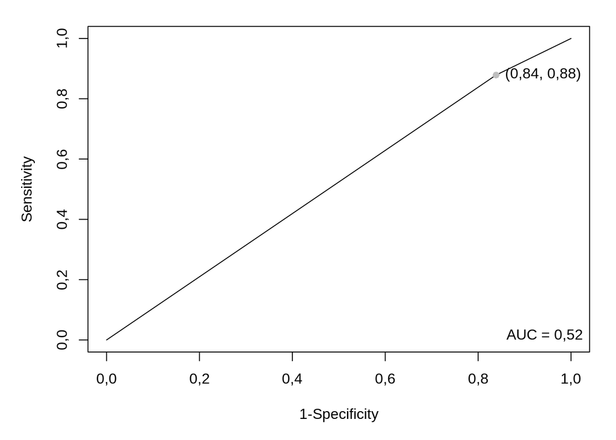

## Таблица с результатами ROC-AUC анализа

Табл. 3. Предсказательная ценность ВПО

| Показатель | Значение |
| --- | --- |
| AUC | 0.520 |
| AUC.SE | 0.053 |
| AUC.low | 0.416 |
| AUC.up | 0.624 |
| ACC | 0.649 |
| ACC.low | 0.645 |
| ACC.up | 0.654 |
| SEN | 0.879 |
| SEN.low | 0.800 |
| SEN.up | 0.958 |
| SPE | 0.161 |
| SPE.low | 0.032 |
| SPE.up | 0.291 |
| PLR | 1.048 |
| PLR.low | 0.877 |
| PLR.up | 1.253 |
| NLR | 0.752 |
| NLR.low | 0.268 |
| NLR.up | 2.111 |
| PPV | 0.690 |
| PPV.low | 0.592 |
| PPV.up | 0.789 |
| NPV | 0.385 |
| NPV.low | 0.120 |
| NPV.up | 0.649 |

# Предсказательная ценность `olfactory.loss` без `hyposmia.before`

Из колонки `hyposmia.before` удалены ответы ‘да’. Все остальное закодировано по тому же принципу.

## График ROC

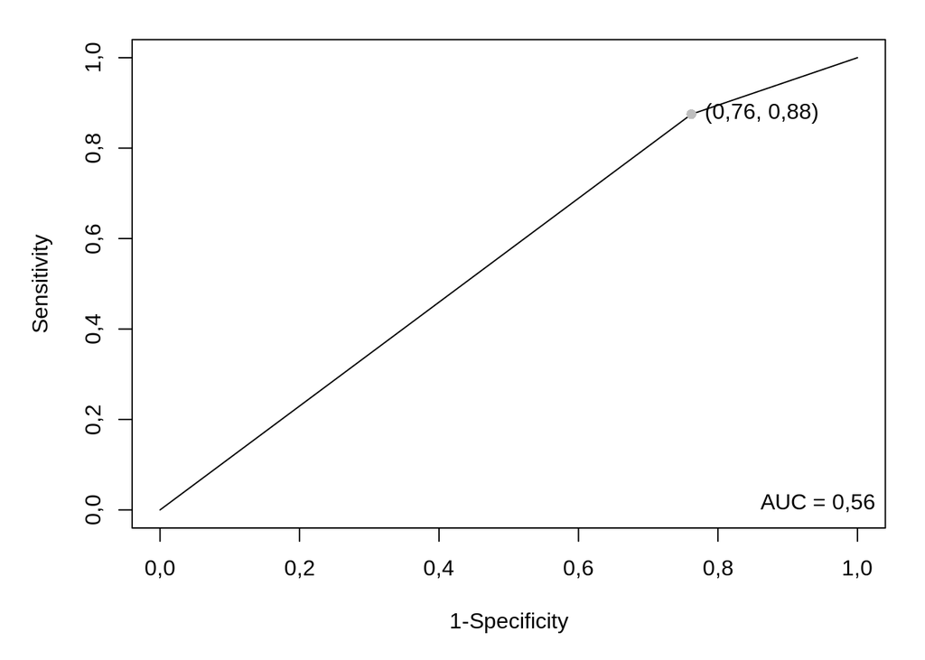

## Таблица с результатами ROC-AUC анализа

Табл. 4. Предсказательная ценность ВПО

| Показатель | Значение |
| --- | --- |
| AUC | 0,557 |
| AUC.SE | 0,069 |
| AUC.low | 0,422 |
| AUC.up | 0,691 |
| ACC | 0,701 |
| ACC.low | 0,696 |
| ACC.up | 0,707 |
| SEN | 0,875 |
| SEN.low | 0,788 |
| SEN.up | 0,962 |
| SPE | 0,238 |
| SPE.low | 0,056 |
| SPE.up | 0,420 |
| PLR | 1,148 |
| PLR.low | 0,887 |
| PLR.up | 1,488 |
| NLR | 0,525 |
| NLR.low | 0,187 |
| NLR.up | 1,474 |
| PPV | 0,754 |
| PPV.low | 0,649 |
| PPV.up | 0,859 |
| NPV | 0,417 |
| NPV.low | 0,138 |
| NPV.up | 0,696 |

## Обе таблицы вместе

Табл. 5. Объединенная таблица предсказательной ценности ВПО

| Показатель | Гипосмия включена | Гипосмия исключена |
| --- | --- | --- |
| AUC | 0.520 | 0,557 |
| AUC.SE | 0.053 | 0,069 |
| AUC.low | 0.416 | 0,422 |
| AUC.up | 0.624 | 0,691 |
| ACC | 0.649 | 0,701 |
| ACC.low | 0.645 | 0,696 |
| ACC.up | 0.654 | 0,707 |
| SEN | 0.879 | 0,875 |
| SEN.low | 0.800 | 0,788 |
| SEN.up | 0.958 | 0,962 |
| SPE | 0.161 | 0,238 |
| SPE.low | 0.032 | 0,056 |
| SPE.up | 0.291 | 0,420 |
| PLR | 1.048 | 1,148 |
| PLR.low | 0.877 | 0,887 |
| PLR.up | 1.253 | 1,488 |
| NLR | 0.752 | 0,525 |
| NLR.low | 0.268 | 0,187 |
| NLR.up | 2.111 | 1,474 |
| PPV | 0.690 | 0,754 |
| PPV.low | 0.592 | 0,649 |
| PPV.up | 0.789 | 0,859 |
| NPV | 0.385 | 0,417 |
| NPV.low | 0.120 | 0,138 |
| NPV.up | 0.649 | 0,696 |

Примечания:

AUC - Area Under Curve

ACC - accuracy

SEN - sensitivity

SPE - specificity

PLR - positive likelihood ratio

NLR - negative likelihood ratio

PPV - positive predictive value

NPV - negative predictive value

**up** и **low** - верхняя и нижняя граница 95% доверительного интервала

**SE** - стандартная ошибка

### Шпаргалка

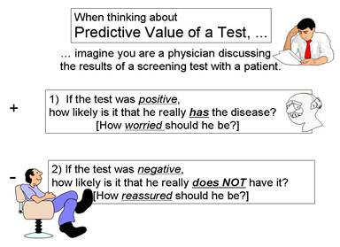

PPV and NPV explanation

# Описательная статистика

## Возраст и пол ~ COVID

Из таблицы ниже удалены COVID=‘в работе’, hyposmia.before=‘да’, пустые ячейки в `olfactory.loss`

### Распределение по возрасту (гистограмма)

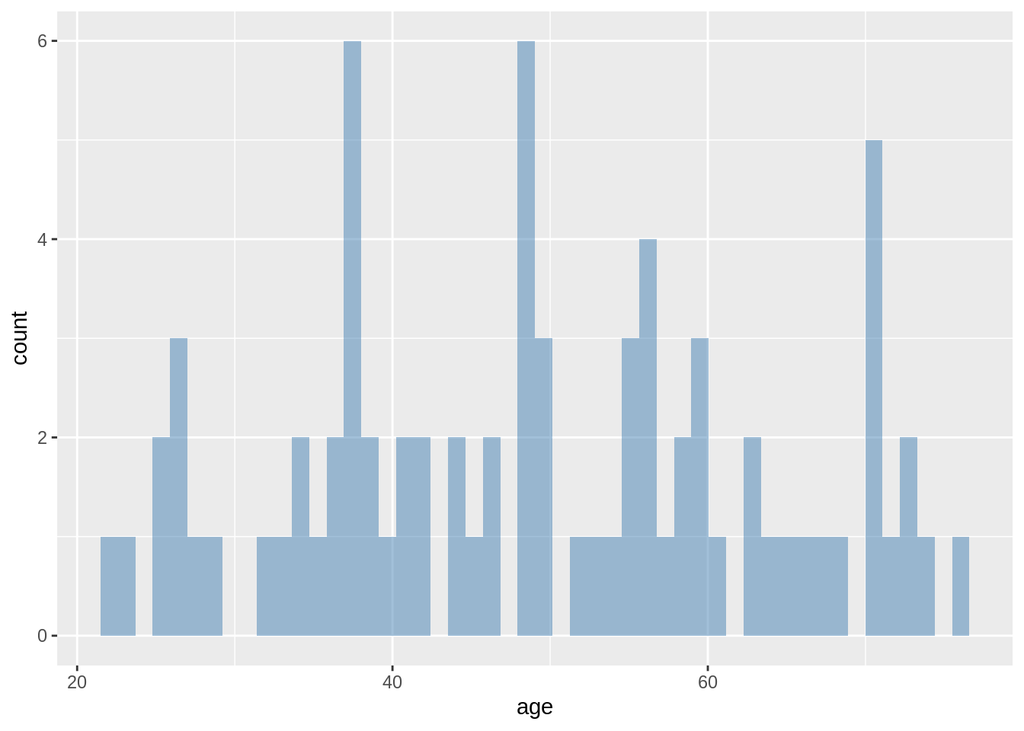

### Распределение возраста с учетом пола

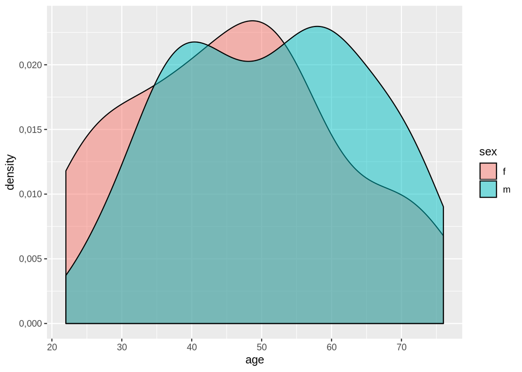

### Распределение возраста с учетом пола ~ COVID (0 - нет, 1 - есть)

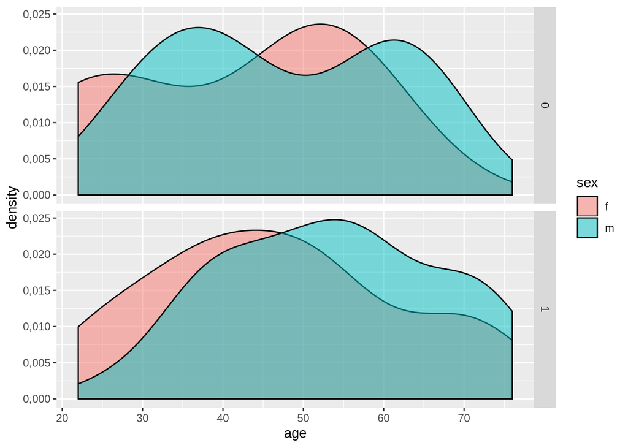

## Распределние возраста с учетом пола + медианные значения возраста у М и Ж ~ olfactory loss (0 - нет, 1 - есть)

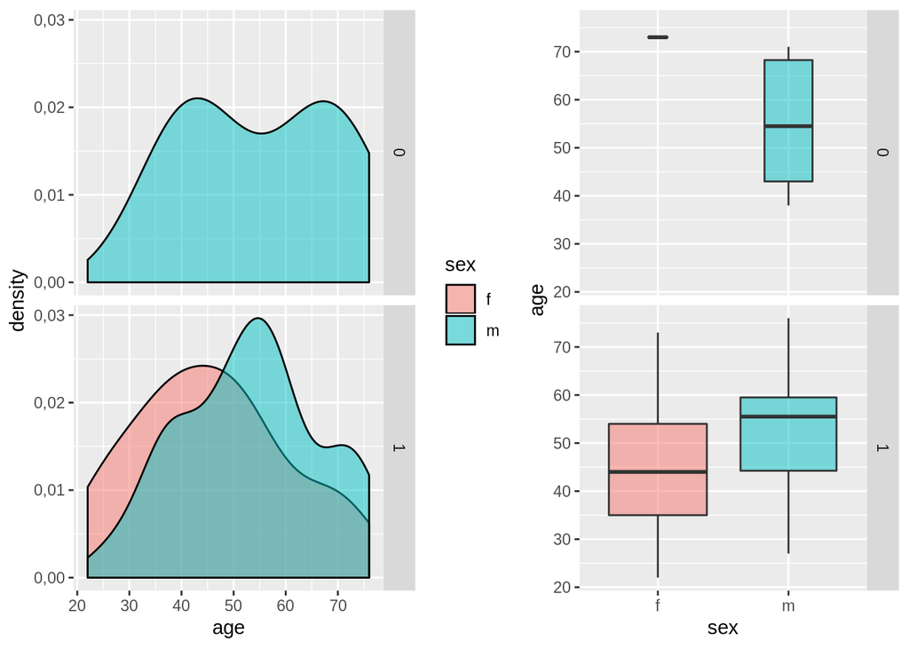

## Регрессия аносмии

### В целом

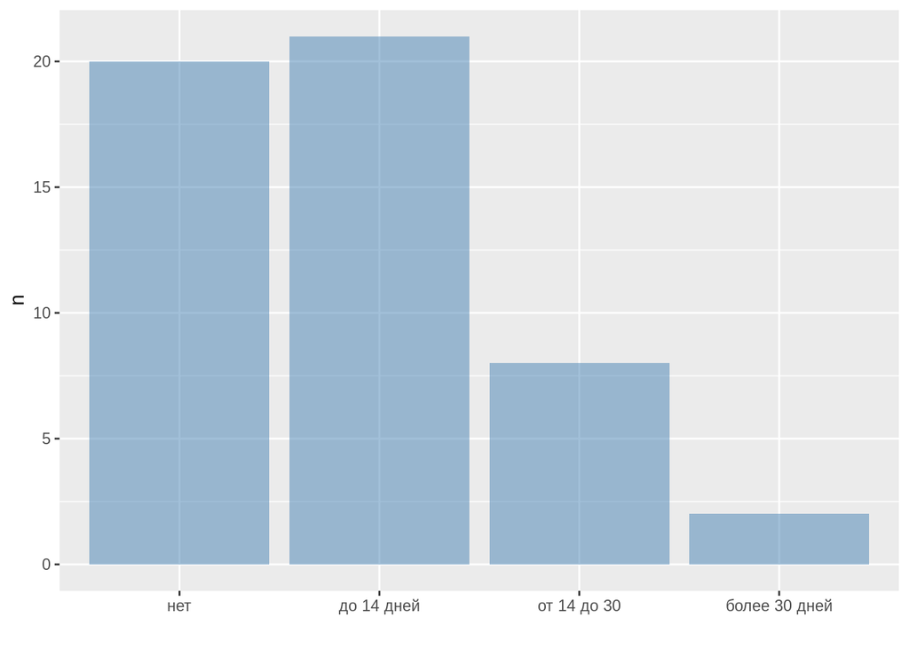

| n.days.regress | n |
| --- | --- |
| нет | 20 |
| до 14 дней | 21 |
| от 14 до 30 | 8 |
| более 30 дней | 2 |
| NA | 5 |

### С учетом пола

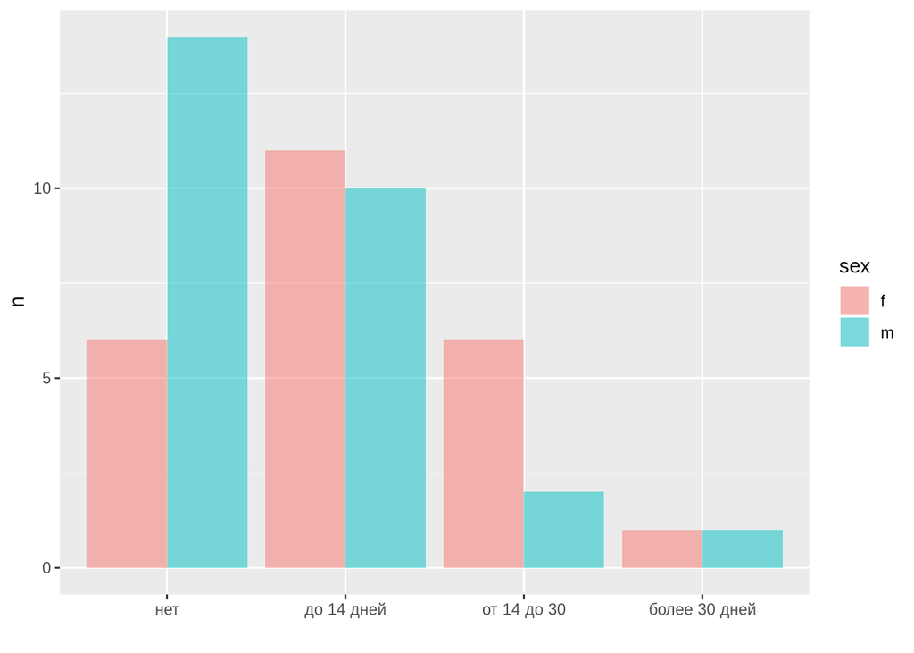

| n.days.regress | sex | n |
| --- | --- | --- |
| нет | f | 6 |
| нет | m | 14 |
| до 14 дней | f | 11 |
| до 14 дней | m | 10 |
| от 14 до 30 | f | 6 |
| от 14 до 30 | m | 2 |
| более 30 дней | f | 1 |
| более 30 дней | m | 1 |
| NA | f | 2 |
| NA | m | 3 |

## Когда замечено

### До или после диагностики

#### В целом

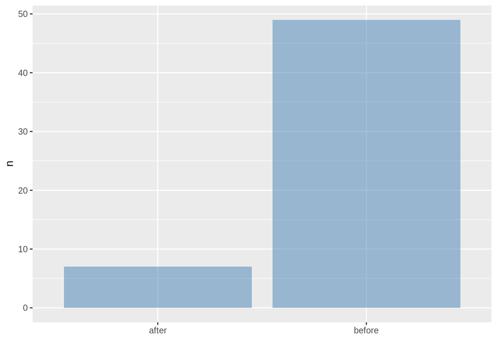

| when.noticed.before.after | n |
| --- | --- |
| after | 7 |
| before | 49 |

#### С учетом пола

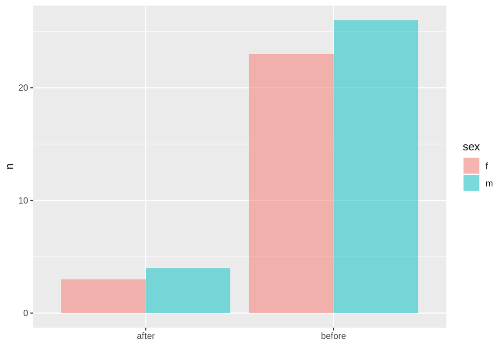

| when.noticed.before.after | sex | n |
| --- | --- | --- |
| after | f | 3 |
| after | m | 4 |
| before | f | 23 |
| before | m | 26 |

#### С учетом пола и возраста

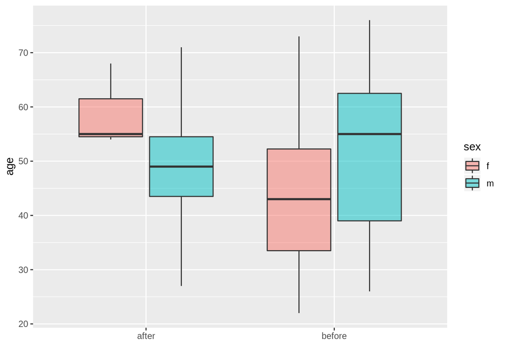

## Когда замeчено с разбивкой по дням

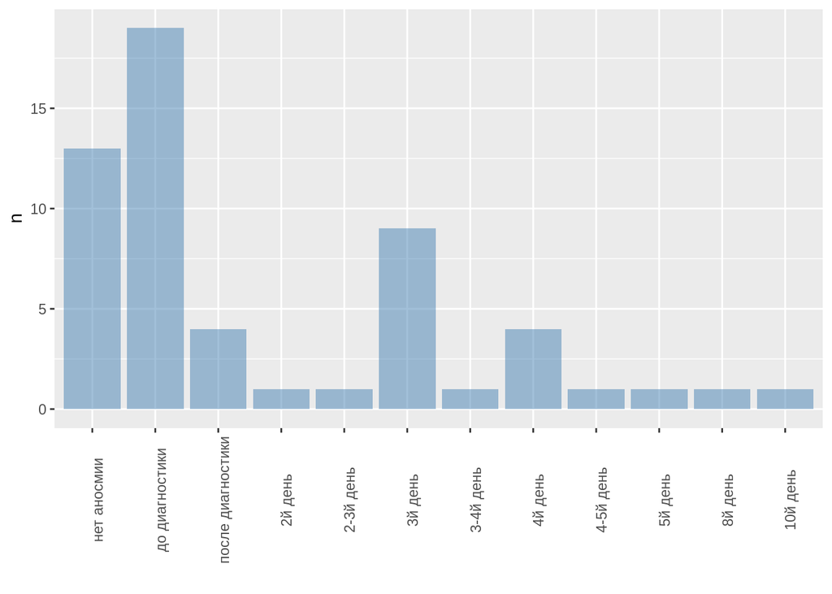

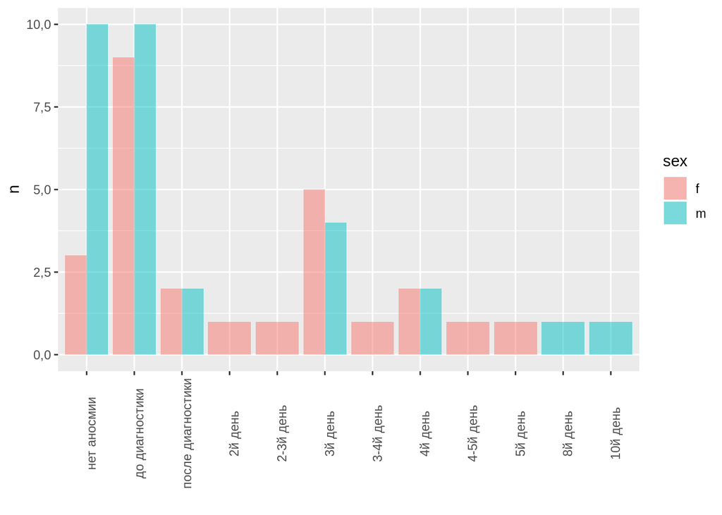

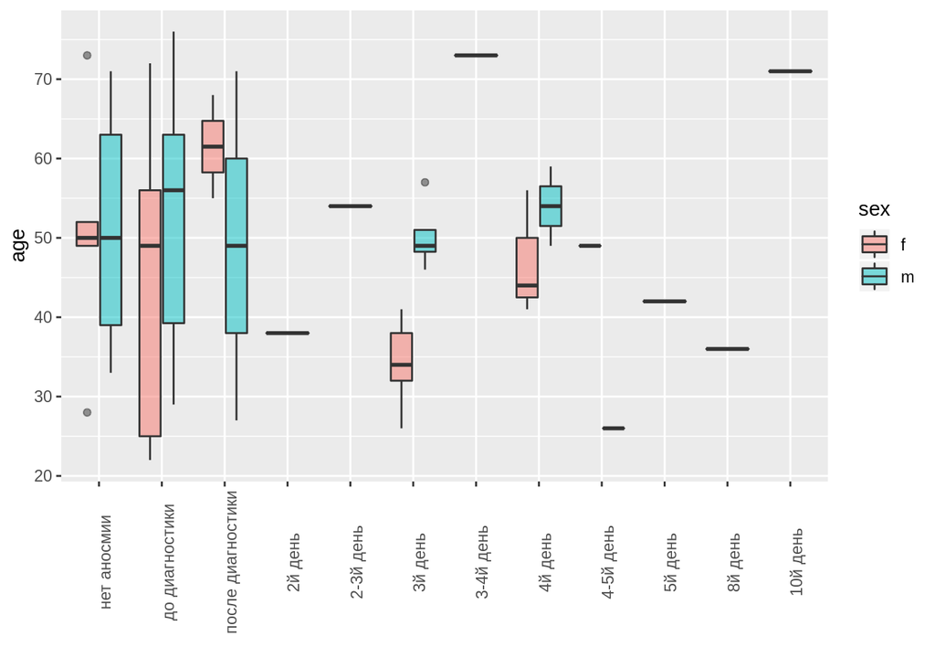

## Другие симптомы

Тут есть загадочная запись “х”, которую я удалил

### Пол и другие симптомы

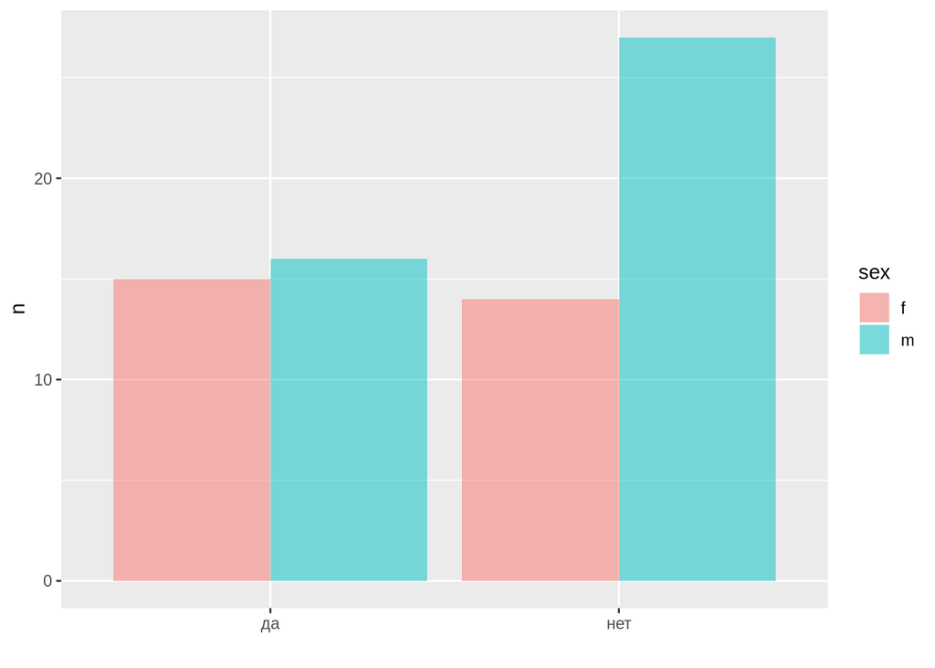

### Потеря обнояния и другие симптомы

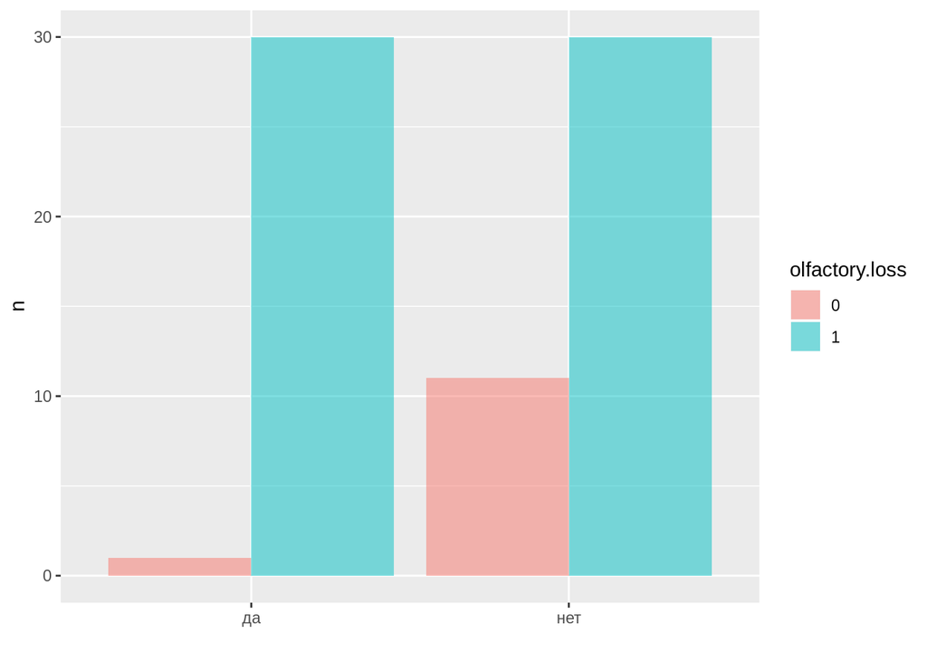

### Возраст и другие симптомы

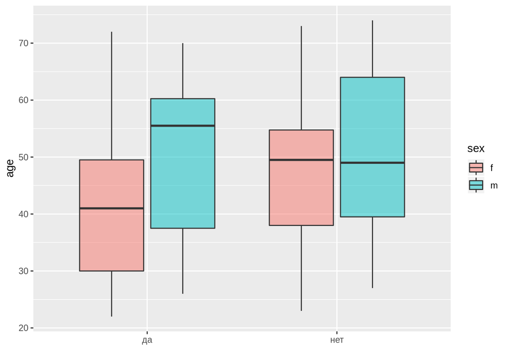

# References

Все статистическе расчеты, обработка данных и визуализация сделаны с помощью языка программирования R [1], пакетов `ggplot2` [2] и `reportROC` [3].

1. R Core Team (2019). R: A language and environment for statistical computing. R Foundation for Statistical Computing, Vienna, Austria. URL https://www.R-project.org/.
2. H. Wickham. ggplot2: Elegant Graphics for Data Analysis. Springer-Verlag New York, 2016.
3. Zhicheng Du and Yuantao Hao (2019). reportROC: An Easy Way to Report ROC Analysis. R package version 3.4. https://CRAN.R-project.org/package=reportROC